# Functions, with WPA09 and solutions (ds4psy)

Hansjörg Neth, SPDS, uni.kn

2019 05 29

# Introduction

This file contains **essential commands** from [Chapter 19: Functions](https://r4ds.had.co.nz/functions.html) of the textbook [r4ds](http://r4ds.had.co.nz) and corresponding examples and exercises. A command is considered “essential” when you really need to *know* it and need to know *how to use* it to succeed in this course.

All [ds4psy](http://rpository.com/ds4psy/) essentials so far:

| Nr. | Topic |
| --- | --- |
| 0. | [Syllabus](http://rpository.com/ds4psy/) |
| 1. | [Basic R concepts and commands](http://rpository.com/ds4psy/essentials/basics.html) |
| 2. | [Visualizing data](http://rpository.com/ds4psy/essentials/visualize.html) |
| 3. | [Transforming data](http://rpository.com/ds4psy/essentials/transform.html) |
| 4. | [Exploring data (EDA)](http://rpository.com/ds4psy/essentials/explore.html) |
| 5. | [Tibbles](http://rpository.com/ds4psy/essentials/tibbles.html) |
| 6. | [Importing data](http://rpository.com/ds4psy/essentials/import.html) |
| 7. | [Tidying data](http://rpository.com/ds4psy/essentials/tidy.html) |
| 8. | [Joining data](http://rpository.com/ds4psy/essentials/join.html) |
| 9. | **Functions** [*](http://rpository.com/ds4psy/essentials/function.html) |
| 10. | [Iteration](http://rpository.com/ds4psy/essentials/iteration.html) |
| +. | [Datasets](http://rpository.com/ds4psy/essentials/datasets.html) |

## Course coordinates

- PSY-15150, at the [University of Konstanz](https://www.uni-konstanz.de/) by [Hansjörg Neth](http://neth.de/) (h.neth@uni.kn, [SPDS](https://www.spds.uni-konstanz.de/), office D507).
- Summer 2019: Mondays, 15:15–16:45, D435.
- Links to current [course syllabus](http://rpository.com/ds4psy/) | [ZeUS](https://zeus.uni-konstanz.de:443/hioserver/pages/startFlow.xhtml?_flowId=detailView-flow&unitId=5101&periodId=179&navigationPosition=hisinoneLehrorganisation,examEventOverviewOwn) | [Ilias](https://ilias.uni-konstanz.de/ilias/goto_ilias_uni_crs_863036.html)
- [ds4psy](https://bookdown.org/hneth/ds4psy/%3E) essentials and WPAs

## Preparations

Create an R script (`.R`) or an R-Markdown file (`.Rmd`) and load the R packages of the `tidyverse`. (**Hint:** Structure your script by inserting spaces, meaningful comments, and sections.)

```r
## Functions | ds4psy
## 2019 01 28
## ----------------------------

## Preparations: ----------

library(tidyverse)

## 1. Topic: ----------

# etc.

## End of file (eof). ----------
```

To use [R Markdown](https://rmarkdown.rstudio.com), create a corresponding file and save it with the `.Rmd` extension (e.g., by selecting `File > New File > R Markdown`). For instructions on combining text and code, see [Chapter 27: R Markdown](https://r4ds.had.co.nz/r-markdown.html) of our textbook, or use one of the following templates:

- minimal template: `rmd_template_s` [in .Rmd | .html format]
- medium template: `rmd_template_m` [in .Rmd | .html format]
- explicit explanations: `Rmarkdown_basics` [in .Rmd | .html format]

**Hint:** Try to *knit* your `.Rmd` file immediately after saving it and marvel at the beauty of the resulting `.html`-file. If this works, keep doing this routinely from now on, putting all your R-code into code chunks, and any text (like headings or conclusions) that describes or explains what you are doing outside of them. From now on, you can share your `.html` output files, rather than your `.Rmd` source files when showing off your R and data science skills.

# Functions

We have been using functions in all sessions of this course. Many of them – like `c()`, `max()`, and `mean()` – are included in R (so-called *base R* functions), and the others – like `mutate()`, `gather()`, and `ggplot()` – were defined in additional packages (e.g., the tidyverse packages `dplyr`, `tidyr`, and `ggplot2`). Actually, the fact that most packages mostly provide additional functions shows that functions are a pretty big deal in R. Like tools, functions extend the scope of tasks that can be solved. To use a tool, we typically do not need to understand how it was designed and built. However, to create new tools in R, we need to know how to write functions.

#### The function of functions

What is a function? Mathematically, a *function* is a mapping between sets, or from a set of elements x to a set y. In the context of computer programming, a function maps inputs to outputs. To use a function, we only need to know its *name* and *purpose*, which *inputs* it takes, and what *outputs* it returns. Unless we want to understand exactly *how* it works or *modify* a function, we learn and use functions without ever seeing how they are defined. Thus, as long as we only use a function, we can think of it as a black box that is defined by its purpose and input-output relations.[^1]

When moving from using functions to writing them, functions are a great way to automate repeated tasks. As each function handles a task and can be understood solely by its mapping from inputs to outputs, functions are powerful tools of abstraction and encapsulation. In a functional programming paradigm (like R), functions are the basic problem solving units: Each function deals with a task (i.e., performs an action, which is why we can think of them as verbs). To use a new set of functions (e.g., an R package) we primarily need to know its overall goal (i.e., which challenge or problem does it address?) and its functions (i.e., which functions does it provide? What does each function do?).

## Basics

The basic structure for writing a new function looks as follows:

```r
name <- function(<args>) {<body>}
```

Thus, writing a function initially requires 3 considerations:

1. What would be a good `name` for the function? Function names should clearly convey their purpose (“Which task does this function solve?”), resemble verbs (ideally say what the function does, e.g., `plot`, or state its output, e.g., `mean`), and should be short (as they will be typed many times).
2. Which *inputs* does the function take? Any input that is necessary for the function to perform its task must to be supplied as a list of arguments `<args>`.
   - Arguments typically include *data* (e.g., scalars, vectors, tables, or anything else that the function uses to perform its task) and can contain additional *details* or *parameters* (e.g., instructions on how something is to be done: Which type of calculation is desired? How should `NA` values be treated? Which color should be used? etc.). Data arguments are typically listed first.
   - Any argument can be *optional* (by including a default value that is used when no argument is provided) or *mandatory* (by not including a default value). It is common to make data arguments mandatory, and use optional arguments for details.
   - If a function calls other functions and we want to allow users to pass arguments to these latter functions, we can add `...` (dot-dot-dot) as a special argument. However, this requires that the functions used within the function can deal with the specific arguments that are provided later, and can cause problems and unexpected results.
3. The `<body>` of a function uses the *inputs* provided by `<args>` to perform the task for which the function is created.
   - Although some functions are only used for their side-effects (e.g., load or save an object, create a graph, etc.), most functions are created to (also) return some sort of *output* (e.g., some computed `result`). This can be done by calling the special function `return` in the function `<body>` (e.g., `return(result)`), typically as its last statement.[^2] Even when the function does not contain an explicit `return` statement, it returns the result of the last expression evaluated in the function.
   - The *output* of a function can assume many different data types (scalar, vector, list, table, etc.). For instance, the result of `1:3 + 3:1` is a vector `4, 4, 4`.

Thus, are more detailed template of a typical function is:

```r
name <- function(arg_1, arg_2 = FALSE) {

  # 1: Check inputs:
  <Verify that arg_1 and arg_2 are appropriate inputs.>

  # 2: Solve task by using arguments & code:
  <Use arg_1 and arg_2 to solve the task.>

  # 3: Collect and assign outputs:
  result <- <The task solution.>

  # 4: Return output:
  return(result)

}
```

Typical uses of this function could look as follows:

```r
# Using this function:
name(arg_1 = x)                 # providing only required argument
name(arg_2 = y, arg_2 = FALSE)  # providing both arguments
name(z, FALSE)                  # providing arguments by argument order
name(z)                         # providing only mandatory (1st) argument
```

## Examples

Here are some examples of simple functions:

#### A power function

```r
power <- function(x, exp = 1) {
  x^exp
}
```

We can describe this function as follows:

- The function `power` has 2 arguments: A mandatory argument `x` and a optional argument `exp` with a default value of `1`.
- The function computes `x^exp` and returns the result (as this is the final statement in the function’s body).
- Thus, the task addressed by `power` is to raise `x` to the `exp`-th power.
- Although the function does not verify anything, `x` and `exp` are assumed to be numeric.

#### Checking the function

It is very important to run a range of checks after writing a new function. When doing these checks, examples that use unusual inputs (like `NA`, `NULL`, or arguments of different types) are particularly informative.

Here are some possible ways of checking how `power` works:

```r
# Check:
power(x = 3)
```

```
#> [1] 3
```

```r
power(x = 3, exp = 2)
```

```
#> [1] 9
```

```r
# Note that the function also works for vectors:
power(x = 1:5, exp = 2)
```

```
#> [1]  1  4  9 16 25
```

```r
power(x = 2,   exp = 1:4)
```

```
#> [1]  2  4  8 16
```

```r
# Omitting argument names:
power(3)     # names can be omitted, and
```

```
#> [1] 3
```

```r
power(3, 2)  # arguments are used in order given.
```

```
#> [1] 9
```

```r
power(1:5, 2)
```

```
#> [1]  1  4  9 16 25
```

```r
power(2, 1:4)
```

```
#> [1]  2  4  8 16
```

```r
# However, when arguments are named:
power(exp = 3, x = 2)  # order is irrelevant.
```

```
#> [1] 8
```

```r
# => Safest way: Always provide argument names!

# Note what happens with NA values:
power(x = NA)
```

```
#> [1] NA
```

```r
power(x = 3, exp = NA)
```

```
#> [1] NA
```

```r
# => NA values are 'contagious'.

## Errors:
# power()       # 1st argument is mandatory
# power("A")    # setting x to non-numeric argument
# power(3, "B") # setting exp to non-numeric argument
```

#### Explicit `return`

A more explicit version of the same function would be:

```r
power <- function(x, exp = 1) {

  result <- x^exp

  return(result)
}
```

Whereas the shorter version of the function relied on returning its *last* (and only) expression, this version makes it more explicit what is being computed and returned. As functions get larger and more complicated, it is generally a good idea to include explicit `return` statements. Importantly, a function can include multiple return statements and is exited as soon as a `return` is reached. For instance, the following variant would never print its final disclaimer:

```r
power_joke <- function(x, exp = 1) {

  result <- x^exp

  return(result)

  "Just kidding"
}
```

#### Practice

Test this last statement by evaluating the `power_joke` function and trying to obtain the `"Just kidding"` line as an output. Then comment out the line `return(result)` and re-run the same checks.

```r
# Checks: ------
power_joke(5)
```

```
#> [1] 5
```

```r
power_joke(5, 2)
```

```
#> [1] 25
```

```r
power_joke(100, 1/2)
```

```
#> [1] 10
```

```r
power_joke(1:5, 2)
```

```
#> [1]  1  4  9 16 25
```

```r
power_joke(NA)
```

```
#> [1] NA
```

```r
# Errors:
# power_joke()
# power_joke("A")

# => "Just kidding" is never reached.


# Commenting out return(result): ------

power_joke <- function(x, exp = 1) {

  result <- x^exp

  # return(result)

  "Just kidding"
}

# Checks:
power_joke(5)
```

```
#> [1] "Just kidding"
```

```r
power_joke(5, 2)
```

```
#> [1] "Just kidding"
```

```r
power_joke(100, 1/2)
```

```
#> [1] "Just kidding"
```

```r
power_joke(1:5, 2)
```

```
#> [1] "Just kidding"
```

```r
power_joke(NA)
```

```
#> [1] "Just kidding"
```

```r
# Errors:
# power_joke()
# power_joke("A")

# => "Just kidding" is always reached
#    (unless an earlier error occurs).
```

#### A descriptive function

Here is another example of a function:

```r
describe <- function(v, rm_na = TRUE){

  if (length(v) == 1 && is.na(v)) { return(v) }

  if (!is.numeric(v)) {
    message("v is not numeric:")
    return(v)
  }

  # Compute some metrics:
  mn <- mean(v, na.rm = rm_na)
  md <- median(v, na.rm = rm_na)
  min <- min(v, na.rm = rm_na)
  max <- max(v, na.rm = rm_na)
  q25 <- quantile(v, .25, na.rm = TRUE)
  q75 <- quantile(v, .75, na.rm = TRUE)
  nr_NA <- sum(is.na(v))

  # Create output vector:
  out <- c(min, q25, md, mn, q75, max, nr_NA)
  names(out) <- c("min", "q25", "md", "mn", "q75", "max", "nr_NA")

  return(out)

}
```

We can describe this function as follows:

- The function `describe` has 2 arguments: A mandatory argument `v` and a optional argument `rm_na` with a default value of `TRUE`.
- The function first checks if `v` is `NA`: If so, it returns `v` (i.e., `NA`).
- The function then checks if `v` is non-numeric: If so, it prints a message and returns `v`.
- The function then computes 7 different statistical measures. This illustrates that functions can use other functions. For some of these functions (e.g., `mean`), the `describe` function passes the value of its optional argument `rm_na` to another function’s `na.rm` argument. However, for another function (`quantile`), the `describe` function does not use its `rm_na` argument, but always provides `na.rm = TRUE`.
- The function then creates a vector `out` that includes the 7 computed measures in a specific order and names the vector.
- The function then returns the vector `out`.
- Overall, the task addressed by `describe` is to provide a range of descriptive statistics of a vector `v`.

#### Checking the function

Here are some possible ways of checking how `describe` works:

```r
# Check:
v <- 1:10
describe(v)
```

```
#>   min   q25    md    mn   q75   max nr_NA
#>  1.00  3.25  5.50  5.50  7.75 10.00  0.00
```

```r
describe(c(NA, v, NA))
```

```
#>   min   q25    md    mn   q75   max nr_NA
#>  1.00  3.25  5.50  5.50  7.75 10.00  2.00
```

```r
describe(v, rm_na = FALSE)
```

```
#>   min   q25    md    mn   q75   max nr_NA
#>  1.00  3.25  5.50  5.50  7.75 10.00  0.00
```

```r
describe(c(v, NA), rm_na = FALSE)
```

```
#>   min   q25    md    mn   q75   max nr_NA
#>    NA  3.25    NA    NA  7.75    NA  1.00
```

```r
# Note:
describe(NA)
```

```
#> [1] NA
```

```r
describe("A")
```

```
#> [1] "A"
```

```r
# Error for:
# describe()
```

Actually, `describe` is – apart from subtle differences – similar to the base R function `summary`:

```r
# Compare with base::summary function:
summary(v)
```

```
#>    Min. 1st Qu.  Median    Mean 3rd Qu.    Max.
#>    1.00    3.25    5.50    5.50    7.75   10.00
```

```r
summary(c(NA, v, NA))
```

```
#>    Min. 1st Qu.  Median    Mean 3rd Qu.    Max.    NA's
#>    1.00    3.25    5.50    5.50    7.75   10.00       2
```

```r
summary(NA)
```

```
#>    Mode    NA's
#> logical       1
```

```r
# Error for:
# summary()
```

## Style

Writing good functions is a life-long aspiration. For starters,

- make sure that you choose good *names* for both your functions and their arguments;
- *format* your functions so that their structure is clear and they are easy to read (i.e., use blank lines between different parts and automatic indentation);
- provide *comments* to explain the function’s purpose and anything else that may be difficult to understand.

## Flow control

Whereas most of our scripts so far relied on being executed linearly (in top-down fashion, line-by-line fashion), using functions implies jumping around in large amounts of code.[^3] In addition, writing new functions often requires controlling the flow of information *within* the body of a function. We can distinguish between several ways of doing this:

- Special functions (e.g., like `return`, `print`, or `stop`) cause side-effects or skip code by exiting functions.
- Many functions rely on *iteration* and *loops*, which are covered in [Chapter 21: Iteration](https://r4ds.had.co.nz/iteration.html).
- Testing input arguments or distinguishing between several cases requires the *conditional* execution of code, which is discussed next.

# Conditionals

As we have just seen in `describe`, functions frequently require checking some properties of its inputs, distinguishing between cases, and controlling the flow of data processing based on test results.

## If-then

A test can be conducted by a *conditional* statement, like the following if-then or `if (test) {...}` structure:

```r
if (test) {    # if: test is TRUE
  print("ok")  # then: print ok
}
```

Here, `test` must evaluate to a single Boolean value (i.e., either `TRUE` or `FALSE`). If `test` is `TRUE` the code in the subsequent `{...}` is executed (here: `"ok"` is printed to the Console) – otherwise the code in the subsequent `{...}` is skipped, as if it was not there or commented out. (Note that if `test` is a Boolean value, we do not need ask for the condition `test == TRUE`.)

#### Example

```r
x <- 101
if (x >= 100) { print(paste0("The number ", x, " is big.")) }
```

```
#> [1] "The number 101 is big."
```

```r
x <- 99
if (x >= 100) { print(paste0("The number ", x, " is big.")) }
# Note that nothing happens here!
```

## If-then-else

If a test fails, we often want something *else* to happen. To accommodate this desire, a slightly more complicated form of `if` statement includes an additional `{...}` after an `else` statement:

```r
if (test) {
  print("case 1")  # if test is TRUE:  case 1
} else {
  print("case 2")  # if test is FALSE: case 2
}
```

Here, the truth value of `test` determines whether the 1st or the 2nd `{...}` is executed. As `test` must be either `TRUE` or `FALSE`, we either see “case 1” printed (if `test` is `TRUE`) or “case 2” printed (if `test` is `FALSE`).

The following sequence illustrates how tests work (and can fail to work):

```r
# (a) test is TRUE:
person <- "daughter"
if (person == "daughter") {print("female")} else {print("male")}
```

```
#> [1] "female"
```

```r
# (b) test is FALSE:
person <- "grandfather"
if (person == "daughter") {print("female")} else {print("male")}
```

```
#> [1] "male"
```

```r
# But:
# (c) test is FALSE, but should be TRUE:
person <- "grandmother"
if (person == "daughter") {print("female")} else {print("male")}
```

```
#> [1] "male"
```

## More complex tests

The condition `test` of a conditional statement can contain multiple tests. If so, each individual test must evaluate to either `TRUE` or `FALSE` and the different tests are linked with `&&` or `||`, which work like the logical connectors `&` and `|`, but are evaluated sequentially (from left to right):

```r
if (test_1 || (test_2 && test_3)) {
  print("case 1")
} else {
  print("case 2")
}
```

#### Example

Here’s a way to fix our problem from above (by providing a more comprehensive test):

```r
# (c) with a more complex test:
if (person == "daughter" || person == "mother" || person == "grandmother") {
  print("female")
} else {
  print("male")
}
```

```
#> [1] "female"
```

## More cases

As we can replace any `{...}` in a conditional statement `if (test) {...} else {...}` by another conditional statement, we can distinguish more than 2 cases:

```r
if (test_1) {        # if test_1 is TRUE:
  print("case 1")    # then: case 1
} else if (test_2) { # if test_2 is TRUE:
  print("case 2")    # then: case 2
} else {             # if NONE of the tests are TRUE:
  print("else")      # then: else case
}
```

Here, 2 cases are contingent on their corresponding condition being `TRUE`, otherwise the final `{...}` is reached and `"else"` is being printed. Thus, an “else case” often serves as a generic case that occurs when none of the earlier tests are true.

Note that the following variant of this conditional is different:

```r
if (test_1) {         # if test_1 is TRUE:
  print("case 1")     # then: case 1
} else if (test_2) {  # if test_2 is TRUE:
  print("case 2")     # then: case 2
} else if (test_3) {  # if NONE of the tests are TRUE, BUT test_3 is TRUE:
  print("else")       # then: else case
}
```

Here, the final `{...}` is contingent on another `test_3` being `TRUE`. Thus, the conditions that the final `"else"` is being printed are not only that `test_1` and `test_2` are both `FALSE` but also that `test_3` is `TRUE`. If all 3 tests fail, none of the cases is reached and nothing is printed.

#### Note

- When a test evaluates to `TRUE`, the corresponding `{...}` is evaluated and any later instances of `test` and `{...}` are skipped. Thus, only a single case of `{...}` is evaluated, even if multiple tests would evaluate to `TRUE`.

## Switch

A useful alternative to overly complicated `if` statements is `switch`, which selects one of a list of alternatives:

```r
do_op <- function(x, y, op) {

  switch(op,
         plus = x + y,
         minus = x - y,
         times = x * y,
         divide = x / y,
         power = x ^ y,
         stop("Unknown operation!")
  )
}

# Check:
do_op(3, 2, "plus")
```

```
#> [1] 5
```

```r
do_op(3, 2, "minus")
```

```
#> [1] 1
```

```r
do_op(3, 2, "power")
```

```
#> [1] 9
```

```r
# But:
# do_op(3, 2, "square_root")  # would reach stop (and yield an Error)
```

Here, `op` was specified as a character variable. If switch is used with a numeric expression `i`, it selects the `i`-th case (with `i` being coerced into an integer). For example:

```r
get_i <- function(v, i = 1) {

  switch(i,
         v[1],
         v[2],
         v[3],
         stop("Unknown case of i!")
  )
}

# Check:
v <- 11:15
get_i(v)
```

```
#> [1] 11
```

```r
get_i(v, 2)
```

```
#> [1] 12
```

```r
get_i(v, 3)
```

```
#> [1] 13
```

```r
## But:
# get_i(v, 4)  # would reach stop (and yield an Error)
```

## Practice

#### A conditional nursery rhyme

Consider the following `check_flow` function:

```r
check_flow <- function(n) {
  if (is.logical(n)) {return("Logo!")} else
  {print("Ok:")}
  if (length(n) == 1 && is.numeric(n))
    {switch(n,print("ene"),print("mene"),print("miste"),
           print("es rappelt"),print("in der kiste"))
  } else if (is.character(n)) {
    if (is.character(n)) {n <- tolower(n)}
    switch(n,"a" = return("ene"),
    "b" = return("mene"),"c" = return("mu"))
  } else {return("Raus bist du!")}
  "(etc.)"}
```

The function appears to implement some nursery rhyme, but is really messy, unfortunately. Hence, we need to clean it up before trying to understand it.

1. Format the function so that it becomes easier to read and parse.

A possible solution would indent commands, place any `}` on a new line, and generally introduce lots of white space, as follows:

```r
check_flow <- function(n) {

  if (is.logical(n)) {
    return("Logo!")
  } else {
    print("Ok:")
  }

  if (length(n) == 1 && is.numeric(n)) {

    switch(n,
           print("ene"),
           print("mene"),
           print("miste"),
           print("es rappelt"),
           print("in der kiste")
    )

  } else if (is.character(n)) {

    if (is.character(n)) {n <- tolower(n)}

    switch(n,
           "a" = return("ene"),
           "b" = return("mene"),
           "c" = return("mu")
    )

  } else {

    return("Raus bist du!")

  }

  "(etc.)"

}
```

2. Describe and try to understand this function. What does it do and how does it do it?
3. Answer the following questions:
   - Which cases does the 1st conditional statement distinguish?
   - When is the 1st `switch` statement reached? When is the 2nd `switch` statement reached?
   - What is the difference between the `print` and the `return` statements?
   - Under which conditions does the function return `"raus bist du"`?
   - What happens when you call `check_flow()` or `check_flow(NA)`?
4. Test your predictions by evaluating the following calls:

```r
# Check:
check_flow(2 < 1)
check_flow(2)
check_flow(4)
check_flow(6)
check_flow(8)
check_flow("A")
check_flow("C")
check_flow("ABC")

# Note:
check_flow()  # yields ERROR: argument "n" missing, with no default
check_flow(NA)
check_flow(sqrt(2))
check_flow(pi)
check_flow(4.1)
check_flow(c(1, 2))
check_flow(c("A", "B")) # yields ERROR in switch: EXPR must be a length 1 vector
```

# Exercises (WPA09)

Here are the exercises of WPA09 and possible solutions for them.

## Exercise 1

Imagine someone proudly presents you the following 3 functions. Each of them takes a vector `v` as an input and tries to perform a simple task. For each function:

- describe the task that the function is designed to perform,
- test whether it successfully performs this task,
- name any problem that you detect with the current function,
- fix the function so that it successfully performs its task.

```r
# (1)  ------
first_element <- function(v) {

  output <- NA   # initialize
  output <- v[1] # set to 1st

}

# Check:
first_element(v = c(10, 11, 12))
first_element(v = c("A", "B", "C"))
first_element(v = c(NA, 11, 12))
first_element(v = NA)

# (2) ------
avg_mn_med <- function(v, na_rm = TRUE) {

  mn  <- mean(v)
  med <- median(v)
  avg <- (mn + med)/2

  return(avg)
}

# Check:
avg_mn_med(v = c(1, 2, 3))
avg_mn_med(v = c(1, 2, 9))
avg_mn_med(v = c(1, 2, NA))
avg_mn_med(v = NA)
avg_mn_med(v = c("A", "B"))

# (3)  ------
mean_sd <- function(v, na_rm = TRUE) {

  mn  <- mean(v)
  sd  <- sd(v)

  both <- c(mn, sd)
  names(both) <- c("mean", "sd")

  return(mn)

}

# Check:
mean_sd(v = c(1, 2, 3))
mean_sd(v = c(1, 2, 9))
mean_sd(v = c(1, 2, NA))
mean_sd(v = NA)
mean_sd(v = c("A", "B"))
```

Possible solutions:

```r
# (1)  ------
# Task: Return the 1st element of v.
# Problem:  Nothing is returned.
# Solution: Add return(output).

first_element <- function(v) {

  output <- NA   # initialize
  output <- v[1] # set to 1st

  return(output)

}

# Check:
first_element(v = c(10, 11, 12))
```

```
#> [1] 10
```

```r
first_element(v = c("A", "B", "C"))
```

```
#> [1] "A"
```

```r
first_element(v = c(NA, 11, 12))
```

```
#> [1] NA
```

```r
first_element(v = NA)
```

```
#> [1] NA
```

```r
# (2) ------
# Task: Return the average of mean and median of v.
# Problem  1: na_rm is not used in function body.
# Solution 1: Add na_rm as value to na.rm of base functions.
# Problem  2: Function returns ERROR for non-numeric v.
# Solution 2: Use if statement to check for is.numeric(v).

avg_mn_med <- function(v, na_rm = TRUE) {

  if (!is.numeric(v)) {
    message("avg_mn_md: v requires numeric inputs.")
  } else {

    mn  <- mean(v, na.rm = na_rm)
    med <- median(v, na.rm = na_rm)
    avg <- (mn + med)/2

    return(avg)

  } # if (!is.numeric(v)) etc.
}

# Check:
avg_mn_med(v = c(1, 2, 3))
```

```
#> [1] 2
```

```r
avg_mn_med(v = c(1, 2, 9))
```

```
#> [1] 3
```

```r
avg_mn_med(v = c(1, 2, NA))
```

```
#> [1] 1.5
```

```r
avg_mn_med(v = NA)
avg_mn_med(v = c("A", "B"))

# (3)  ------
# Task: Return the mean and sd of v.
# Problem  1: Only the mean is returned.
# Solution 1: return(both)
# Problem  2: na_rm is not used in function body.
# Solution 2: Add na_rm as value to na.rm of base functions.
# Problem  3: Function returns ERROR for non-numeric v.
# Solution 3: Use if statement to check for is.numeric(v).

mean_sd <- function(v, na_rm = TRUE) {

  if (!is.numeric(v)) {
    message("mean_sd: v requires numeric inputs.")
  } else {

    mn  <- mean(v, na.rm = na_rm)
    sd  <- sd(v, na.rm = na_rm)

    both <- c(mn, sd)
    names(both) <- c("mean", "sd")

    return(both)

  } # if (!is.numeric(v)) etc.

}

# Check:
mean_sd(v = c(1, 2, 3))
```

```
#> mean   sd
#>    2    1
```

```r
mean_sd(v = c(1, 2, 9))
```

```
#>     mean       sd
#> 4.000000 4.358899
```

```r
mean_sd(v = c(1, 2, NA))
```

```
#>      mean        sd
#> 1.5000000 0.7071068
```

```r
mean_sd(v = NA)
mean_sd(v = c("A", "B"))
```

## Exercise 2

#### Conditional feeding

Let’s write a first function and then add some conditions to it.

1. Write a function `feed_me` that takes a character string `food` as a required argument, and returns the sentence `"I love to eat ___!"`. Test your function by running `feed_me("apples")`, etc. Here’s a template with some blanks, to get you started:

```r
feed_me <- function(___) {

  output <- paste0("I love to eat ", ___, "!")

  print(___)
}
```

A possible solution:

```r
feed_me <- function(food) {

  output <- paste0("I love to eat ", food, "!")

  print(output)
  }

# Check:
feed_me("apples")
```

```
#> [1] "I love to eat apples!"
```

```r
feed_me("books")
```

```
#> [1] "I love to eat books!"
```

```r
feed_me("cake")
```

```
#> [1] "I love to eat cake!"
```

```r
feed_me(NA)
```

```
#> [1] "I love to eat NA!"
```

2. Modify `feed_me` so that it returns `"Nothing to eat."` when `food = NA`.

A possible solution:

```r
feed_me <- function(food) {

  if (is.na(food)) {
    output <- "Nothing to eat."
  } else {
    output <- paste0("I love to eat ", food, "!")
  }

  print(output)
}

# Check:
feed_me(NA)
```

```
#> [1] "Nothing to eat."
```

```r
feed_me("apples")
```

```
#> [1] "I love to eat apples!"
```

```r
feed_me("books")
```

```
#> [1] "I love to eat books!"
```

3. Extend your function to a `feed_vegan` function that uses 2 additional arguments:
   - `type` should be an optional character string, set to a default argument of `"food"`. If `type` is not `"food"`, the function should return `"___ is not edible."`.
   - `vegan` should be an optional Boolean value, which is set to `FALSE` by default. If `vegan` is `TRUE`, the function should return `"I love to eat ___!"`. Otherwise, the function should return `"I do not eat ___."`.

Test each of your functions by evaluating appropriate function calls.

A possible solution:

```r
feed_vegan <- function(food, type = "food", vegan = FALSE) {

  if (is.na(food)) {

    output <- "Nothing to eat."

  } else {  # food is not NA:

    if (type != "food") {
      output <- paste0(food, " is not edible.")
    } else {  # type == "food":

      if (vegan) {
        output <- paste0("I love to eat ", food, "!")
      } else {  # vegan
        output <- paste0("I do not eat ", food, ".")
      }
    }
  }

  print(output)
}

# Check:
feed_vegan(NA)
```

```
#> [1] "Nothing to eat."
```

```r
feed_vegan("veggies", vegan = TRUE)
```

```
#> [1] "I love to eat veggies!"
```

```r
feed_vegan("R4DS", type = "book")
```

```
#> [1] "R4DS is not edible."
```

```r
feed_vegan("meat", vegan = FALSE)
```

```
#> [1] "I do not eat meat."
```

```r
# but:
feed_vegan("spagetti", type = "pasta")  # due to type != "food"
```

```
#> [1] "spagetti is not edible."
```

```r
feed_vegan("veggies")  # due to default: vegan = FALSE
```

```
#> [1] "I do not eat veggies."
```

## Exercise 3

#### Number recognition

This exercise analyzes and corrects someone else’s function.

1. Explain what the following function `describe` (not to be confused with `describe` above) *intends* to do and why it fails in doing it.

```r
describe <- function(x) {

  if (x %% 2 == 0) {print("x is an even number.")}
  else if (x %% 2 == 1) {print("x is an odd number.")}
  else if (x < 1) {print("x is too small.")}
  else if (x > 20) {print("x is too big.")}
  else if (x == 13) {print("x is a lucky number.")}
  else {print("x is beyond description.")}

}
```

#### Solution

The function `describe` seems to want to categorize a number `x` into one of various cases:

- numbers that are too small numbers vs. too big
- odd vs. even numbers
- 13 as a lucky number
- numbers that cannot be described

However, it currently fails (and only distinguishes between even and odd numbers), because of the order of its if statements. Currently, the quite general tests at the beginning are `TRUE` for most cases, so that more specific later cases are never reached.

2. Repair the `describe` function to yield the following results:

```r
# Desired results:
describe(0)
```

```
#> [1] "x is too small."
```

```r
describe(1)
```

```
#> [1] "x is an odd number."
```

```r
describe(13)
```

```
#> [1] "x is a lucky number."
```

```r
describe(20)
```

```
#> [1] "x is an even number."
```

```r
describe(21)
```

```
#> [1] "x is too big."
```

#### Solution

To repair the function, we need to re-arrange the if statements (putting some more specific statements before more general ones):

```r
describe <- function(x) {

  if (x < 1)            {print("x is too small.")}
  else if (x > 20)      {print("x is too big.")}
  else if (x == 13)     {print("x is a lucky number.")}
  else if (x %% 2 == 0) {print("x is an even number.")}
  else if (x %% 2 == 1) {print("x is an odd number.")}
  else                  {print("x is beyond description.")}

}

# Check:
describe(0)
```

```
#> [1] "x is too small."
```

```r
describe(1)
```

```
#> [1] "x is an odd number."
```

```r
describe(13)
```

```
#> [1] "x is a lucky number."
```

```r
describe(20)
```

```
#> [1] "x is an even number."
```

```r
describe(21)
```

```
#> [1] "x is too big."
```

3. What are the results of `describe(NA)` and `describe("one")`? Correct the function to yield appropriate results in both cases.

#### Solution

```r
# Check:
# describe(NA)   # yields an ERROR
describe("one")  # yields "x is too big."
```

```
#> [1] "x is too big."
```

```r
"one" > 20       # is TRUE!
```

```
#> [1] TRUE
```

```r
# Correction:
describe <- function(x) {

  # stopifnot(!is.na(x))  # would yield an error if is.na(x)

  if (is.na(x))         {print("x is NA.")}
  else if (is.character(x)) {print("x is a word.")}

  else if (x < 1)       {print("x is too small.")}
  else if (x > 20)      {print("x is too big.")}
  else if (x == 13)     {print("x is a lucky number.")}
  else if (x %% 2 == 0) {print("x is an even number.")}
  else if (x %% 2 == 1) {print("x is an odd number.")}
  else                  {print("x is beyond description.")}

}

# Check:
describe(NA)     # yields an ERROR
```

```
#> [1] "x is NA."
```

```r
describe("one")  # yields "x is too big."
```

```
#> [1] "x is a word."
```

4. For what kind of `x` will `describe` print `"x is beyond description."`?

#### Solution

The function `describe` prints `"x is beyond description."` for values of `1 < x < 20` that are not integers:

```r
# For 1 < x < 20 that are not integers:
describe(2.2)
```

```
#> [1] "x is beyond description."
```

```r
describe(sqrt(2))
```

```
#> [1] "x is beyond description."
```

```r
describe(pi)
```

```
#> [1] "x is beyond description."
```

## Exercise 4

#### Tibble charts

This exercise writes a function to extract rows from tabular inputs based on the top values of some variable.

1. Write a `top_3` function that takes a tibble `data` and a the column number `col_nr` of a *numeric* variable as its 2 inputs and returns the top-3 rows of the tibble after it has been sorted (in descending order) by the specified column number.

Use the data of `sw <- dplyr::starwars` to illustrate your function.

**Hint:** To write this function, first solve its task for a specific case (e.g., for `col_nr = 2`). When using the `dplyr` commands of the `tidyverse`, a problem you will encounter is that a tibble’s variables are typically referenced by their *unquoted* names, rather than by their number (or column index). Here are 2 ways to solve this problem:

```
- To obtain the unquoted name `some_name` of a given character string `"some_name"`, you can call `!!sym("some_name")`.

- Rather than aiming for a `tidyverse` solution, you could solve the problem with base R commands.
In this case, look up and use the command `order` to re-arrange the rows of a tibble or data frame.
```

#### Solution

A possible tidyverse solution:

```r
# Data:
sw <- dplyr::starwars

# (a) specific solution:
# dplyr-pipe solution uses unquoted variable name:
sw %>% arrange(desc(height)) %>% slice(1:3)
```

```
#> # A tibble: 3 x 13
#>   name  height  mass hair_color skin_color eye_color birth_year gender
#>   <chr>  <int> <dbl> <chr>      <chr>      <chr>          <dbl> <chr>
#> 1 Yara…    264    NA none       white      yellow            NA male
#> 2 Tarf…    234   136 brown      brown      blue              NA male
#> 3 Lama…    229    88 none       grey       black             NA male
#> # … with 5 more variables: homeworld <chr>, species <chr>, films <list>,
#> #   vehicles <list>, starships <list>
```

```r
# (b) Same pipe with a quoted variable name:
sw %>% arrange(desc(!!sym("height"))) %>% slice(1:3)
```

```
#> # A tibble: 3 x 13
#>   name  height  mass hair_color skin_color eye_color birth_year gender
#>   <chr>  <int> <dbl> <chr>      <chr>      <chr>          <dbl> <chr>
#> 1 Yara…    264    NA none       white      yellow            NA male
#> 2 Tarf…    234   136 brown      brown      blue              NA male
#> 3 Lama…    229    88 none       grey       black             NA male
#> # … with 5 more variables: homeworld <chr>, species <chr>, films <list>,
#> #   vehicles <list>, starships <list>
```

```r
# (c) Translation into a function:
top_3 <- function(data, col_nr){

  col_name <- names(data)[col_nr]

  result <- data %>%
    arrange(desc(!!sym(col_name))) %>%
    slice(1:3)

  return(result)

}

# Check:
top_3(sw, 2)  # top_3 height values
```

```
#> # A tibble: 3 x 13
#>   name  height  mass hair_color skin_color eye_color birth_year gender
#>   <chr>  <int> <dbl> <chr>      <chr>      <chr>          <dbl> <chr>
#> 1 Yara…    264    NA none       white      yellow            NA male
#> 2 Tarf…    234   136 brown      brown      blue              NA male
#> 3 Lama…    229    88 none       grey       black             NA male
#> # … with 5 more variables: homeworld <chr>, species <chr>, films <list>,
#> #   vehicles <list>, starships <list>
```

```r
top_3(sw, 3)  # top_3 mass values
```

```
#> # A tibble: 3 x 13
#>   name  height  mass hair_color skin_color eye_color birth_year gender
#>   <chr>  <int> <dbl> <chr>      <chr>      <chr>          <dbl> <chr>
#> 1 Jabb…    175  1358 <NA>       green-tan… orange           600 herma…
#> 2 Grie…    216   159 none       brown, wh… green, y…         NA male
#> 3 IG-88    200   140 none       metal      red               15 none
#> # … with 5 more variables: homeworld <chr>, species <chr>, films <list>,
#> #   vehicles <list>, starships <list>
```

```r
top_3(sw, 7)  # top_3 birth_year values
```

```
#> # A tibble: 3 x 13
#>   name  height  mass hair_color skin_color eye_color birth_year gender
#>   <chr>  <int> <dbl> <chr>      <chr>      <chr>          <dbl> <chr>
#> 1 Yoda      66    17 white      green      brown            896 male
#> 2 Jabb…    175  1358 <NA>       green-tan… orange           600 herma…
#> 3 Chew…    228   112 brown      unknown    blue             200 male
#> # … with 5 more variables: homeworld <chr>, species <chr>, films <list>,
#> #   vehicles <list>, starships <list>
```

```r
# But:
top_3(sw, 1)  # character variables are ordered against alphabetical sequence
```

```
#> # A tibble: 3 x 13
#>   name  height  mass hair_color skin_color eye_color birth_year gender
#>   <chr>  <int> <dbl> <chr>      <chr>      <chr>          <dbl> <chr>
#> 1 Zam …    168    55 blonde     fair, gre… yellow            NA female
#> 2 Yoda      66    17 white      green      brown            896 male
#> 3 Yara…    264    NA none       white      yellow            NA male
#> # … with 5 more variables: homeworld <chr>, species <chr>, films <list>,
#> #   vehicles <list>, starships <list>
```

A solution using only base-R functions (here: `order`):

```r
# Data:
sw <- dplyr::starwars

# (a) specific solution for sorting data:
# using order() function and a variable name:
sw[order(-sw$height), ]
```

```
#> # A tibble: 87 x 13
#>    name  height  mass hair_color skin_color eye_color birth_year gender
#>    <chr>  <int> <dbl> <chr>      <chr>      <chr>          <dbl> <chr>
#>  1 Yara…    264    NA none       white      yellow          NA   male
#>  2 Tarf…    234   136 brown      brown      blue            NA   male
#>  3 Lama…    229    88 none       grey       black           NA   male
#>  4 Chew…    228   112 brown      unknown    blue           200   male
#>  5 Roos…    224    82 none       grey       orange          NA   male
#>  6 Grie…    216   159 none       brown, wh… green, y…       NA   male
#>  7 Taun…    213    NA none       grey       black           NA   female
#>  8 Rugo…    206    NA none       green      orange          NA   male
#>  9 Tion…    206    80 none       grey       black           NA   male
#> 10 Dart…    202   136 none       white      yellow          41.9 male
#> # … with 77 more rows, and 5 more variables: homeworld <chr>,
#> #   species <chr>, films <list>, vehicles <list>, starships <list>
```

```r
# Note:
sw$height # is a vector (of height values)
```

```
#>  [1] 172 167  96 202 150 178 165  97 183 182 188 180 228 180 173 175 170
#> [18] 180  66 170 183 200 190 177 175 180 150  NA  88 160 193 191 170 196
#> [35] 224 206 183 137 112 183 163 175 180 178  94 122 163 188 198 196 171
#> [52] 184 188 264 188 196 185 157 183 183 170 166 165 193 191 183 168 198
#> [69] 229 213 167  79  96 193 191
#>  [ reached getOption("max.print") -- omitted 12 entries ]
```

```r
sw[ , 2]  # is the same vector (as column of sw)
```

```
#> # A tibble: 87 x 1
#>    height
#>     <int>
#>  1    172
#>  2    167
#>  3     96
#>  4    202
#>  5    150
#>  6    178
#>  7    165
#>  8     97
#>  9    183
#> 10    182
#> # … with 77 more rows
```

```r
# (b) specific solution for sorting data:
# using order() function and the variable's column number:
sw[order(-sw[ , 2]), ]
```

```
#> # A tibble: 87 x 13
#>    name  height  mass hair_color skin_color eye_color birth_year gender
#>    <chr>  <int> <dbl> <chr>      <chr>      <chr>          <dbl> <chr>
#>  1 Yara…    264    NA none       white      yellow          NA   male
#>  2 Tarf…    234   136 brown      brown      blue            NA   male
#>  3 Lama…    229    88 none       grey       black           NA   male
#>  4 Chew…    228   112 brown      unknown    blue           200   male
#>  5 Roos…    224    82 none       grey       orange          NA   male
#>  6 Grie…    216   159 none       brown, wh… green, y…       NA   male
#>  7 Taun…    213    NA none       grey       black           NA   female
#>  8 Rugo…    206    NA none       green      orange          NA   male
#>  9 Tion…    206    80 none       grey       black           NA   male
#> 10 Dart…    202   136 none       white      yellow          41.9 male
#> # … with 77 more rows, and 5 more variables: homeworld <chr>,
#> #   species <chr>, films <list>, vehicles <list>, starships <list>
```

```r
# (c) Translation into a function:
top_3_base <- function(data, col_nr){

  sorted_data <- data[order(-data[ , col_nr]), ]

  result <- sorted_data[1:3, ]  # top 3 rows

  return(result)

}

# Check:
top_3_base(sw, 2)  # top_3 height values
```

```
#> # A tibble: 3 x 13
#>   name  height  mass hair_color skin_color eye_color birth_year gender
#>   <chr>  <int> <dbl> <chr>      <chr>      <chr>          <dbl> <chr>
#> 1 Yara…    264    NA none       white      yellow            NA male
#> 2 Tarf…    234   136 brown      brown      blue              NA male
#> 3 Lama…    229    88 none       grey       black             NA male
#> # … with 5 more variables: homeworld <chr>, species <chr>, films <list>,
#> #   vehicles <list>, starships <list>
```

```r
top_3_base(sw, 3)  # top_3 mass values
```

```
#> # A tibble: 3 x 13
#>   name  height  mass hair_color skin_color eye_color birth_year gender
#>   <chr>  <int> <dbl> <chr>      <chr>      <chr>          <dbl> <chr>
#> 1 Jabb…    175  1358 <NA>       green-tan… orange           600 herma…
#> 2 Grie…    216   159 none       brown, wh… green, y…         NA male
#> 3 IG-88    200   140 none       metal      red               15 none
#> # … with 5 more variables: homeworld <chr>, species <chr>, films <list>,
#> #   vehicles <list>, starships <list>
```

```r
top_3_base(sw, 7)  # top_3 birth_year values
```

```
#> # A tibble: 3 x 13
#>   name  height  mass hair_color skin_color eye_color birth_year gender
#>   <chr>  <int> <dbl> <chr>      <chr>      <chr>          <dbl> <chr>
#> 1 Yoda      66    17 white      green      brown            896 male
#> 2 Jabb…    175  1358 <NA>       green-tan… orange           600 herma…
#> 3 Chew…    228   112 brown      unknown    blue             200 male
#> # … with 5 more variables: homeworld <chr>, species <chr>, films <list>,
#> #   vehicles <list>, starships <list>
```

```r
# But:
# top_3_base(sw, 1)  # would yield an error, as order does not allow "-" for character variables.
```

2. What happens in your `top_3` function when `col_nr` refers to a *character* variable (e.g., `dplyr::starwars[ , 1]`)? Adjust the function so that its result varies by the type of the variable designated by the `col_nr` argument:
   - if the corresponding variable is a character variable, sort the data in ascending order (alphabetically);
   - if the corresponding variable is a numeric variable, sort the data in descending order (from high to low).

#### Solution

Adjusted tidyverse solution:

```r
# What happens?
top_3(sw, 1)  # character variables are ordered against alphabetical sequence
```

```
#> # A tibble: 3 x 13
#>   name  height  mass hair_color skin_color eye_color birth_year gender
#>   <chr>  <int> <dbl> <chr>      <chr>      <chr>          <dbl> <chr>
#> 1 Zam …    168    55 blonde     fair, gre… yellow            NA female
#> 2 Yoda      66    17 white      green      brown            896 male
#> 3 Yara…    264    NA none       white      yellow            NA male
#> # … with 5 more variables: homeworld <chr>, species <chr>, films <list>,
#> #   vehicles <list>, starships <list>
```

```r
# Preparation: How can we determine the variable type?
# character variable:
sw$name   # a vector name in sw
```

```
#>  [1] "Luke Skywalker"        "C-3PO"
#>  [3] "R2-D2"                 "Darth Vader"
#>  [5] "Leia Organa"           "Owen Lars"
#>  [7] "Beru Whitesun lars"    "R5-D4"
#>  [9] "Biggs Darklighter"     "Obi-Wan Kenobi"
#> [11] "Anakin Skywalker"      "Wilhuff Tarkin"
#> [13] "Chewbacca"             "Han Solo"
#> [15] "Greedo"                "Jabba Desilijic Tiure"
#> [17] "Wedge Antilles"        "Jek Tono Porkins"
#> [19] "Yoda"                  "Palpatine"
#> [21] "Boba Fett"             "IG-88"
#> [23] "Bossk"                 "Lando Calrissian"
#> [25] "Lobot"                 "Ackbar"
#> [27] "Mon Mothma"            "Arvel Crynyd"
#> [29] "Wicket Systri Warrick" "Nien Nunb"
```

[output cut: 24 more lines]

```r
sw[ , 1]  # 1st column of sw
```

```
#> # A tibble: 87 x 1
#>    name
#>    <chr>
#>  1 Luke Skywalker
#>  2 C-3PO
#>  3 R2-D2
#>  4 Darth Vader
#>  5 Leia Organa
#>  6 Owen Lars
#>  7 Beru Whitesun lars
#>  8 R5-D4
#>  9 Biggs Darklighter
#> 10 Obi-Wan Kenobi
#> # … with 77 more rows
```

```r
typeof(sw$name)  # character
```

```
#> [1] "character"
```

```r
typeof(sw[ , 1]) # list!
```

```
#> [1] "list"
```

```r
typeof(unlist(sw[ , 1])) # character !!
```

```
#> [1] "character"
```

```r
# numeric variable:
sw$height  # a vector height in sw
```

```
#>  [1] 172 167  96 202 150 178 165  97 183 182 188 180 228 180 173 175 170
#> [18] 180  66 170 183 200 190 177 175 180 150  NA  88 160 193 191 170 196
#> [35] 224 206 183 137 112 183 163 175 180 178  94 122 163 188 198 196 171
#> [52] 184 188 264 188 196 185 157 183 183 170 166 165 193 191 183 168 198
#> [69] 229 213 167  79  96 193 191
#>  [ reached getOption("max.print") -- omitted 12 entries ]
```

```r
sw[ , 2]   # 2nd column of sw
```

```
#> # A tibble: 87 x 1
#>    height
#>     <int>
#>  1    172
#>  2    167
#>  3     96
#>  4    202
#>  5    150
#>  6    178
#>  7    165
#>  8     97
#>  9    183
#> 10    182
#> # … with 77 more rows
```

```r
typeof(sw$height)  # integer
```

```
#> [1] "integer"
```

```r
typeof(sw[ , 2])   # list!
```

```
#> [1] "list"
```

```r
typeof(unlist(sw[ , 2])) # integer !!
```

```
#> [1] "integer"
```

```r
# Adjusting function from above:
top_3 <- function(data, col_nr){

  col_name <- names(data)[col_nr]
  col_type <- typeof(unlist(data[ , col_nr]))

  if (col_type == "character") {

    result <- data %>%
      arrange(!!sym(col_name)) %>%  # do NOT use desc()
      slice(1:3)

  } else {  # col_type != "character"

    result <- data %>%
      arrange(desc(!!sym(col_name))) %>%
      slice(1:3)

  }

  return(result)

}

# Check:
top_3(sw, 2)  # top_3 height values
```

```
#> # A tibble: 3 x 13
#>   name  height  mass hair_color skin_color eye_color birth_year gender
#>   <chr>  <int> <dbl> <chr>      <chr>      <chr>          <dbl> <chr>
#> 1 Yara…    264    NA none       white      yellow            NA male
#> 2 Tarf…    234   136 brown      brown      blue              NA male
#> 3 Lama…    229    88 none       grey       black             NA male
#> # … with 5 more variables: homeworld <chr>, species <chr>, films <list>,
#> #   vehicles <list>, starships <list>
```

```r
top_3(sw, 3)  # top_3 mass values
```

```
#> # A tibble: 3 x 13
#>   name  height  mass hair_color skin_color eye_color birth_year gender
#>   <chr>  <int> <dbl> <chr>      <chr>      <chr>          <dbl> <chr>
#> 1 Jabb…    175  1358 <NA>       green-tan… orange           600 herma…
#> 2 Grie…    216   159 none       brown, wh… green, y…         NA male
#> 3 IG-88    200   140 none       metal      red               15 none
#> # … with 5 more variables: homeworld <chr>, species <chr>, films <list>,
#> #   vehicles <list>, starships <list>
```

```r
top_3(sw, 7)  # top_3 birth_year values
```

```
#> # A tibble: 3 x 13
#>   name  height  mass hair_color skin_color eye_color birth_year gender
#>   <chr>  <int> <dbl> <chr>      <chr>      <chr>          <dbl> <chr>
#> 1 Yoda      66    17 white      green      brown            896 male
#> 2 Jabb…    175  1358 <NA>       green-tan… orange           600 herma…
#> 3 Chew…    228   112 brown      unknown    blue             200 male
#> # … with 5 more variables: homeworld <chr>, species <chr>, films <list>,
#> #   vehicles <list>, starships <list>
```

```r
# AND now:
top_3(sw, 1)  # name in alphabetical order
```

```
#> # A tibble: 3 x 13
#>   name  height  mass hair_color skin_color eye_color birth_year gender
#>   <chr>  <int> <dbl> <chr>      <chr>      <chr>          <dbl> <chr>
#> 1 Ackb…    180    83 none       brown mot… orange          41   male
#> 2 Adi …    184    50 none       dark       blue            NA   female
#> 3 Anak…    188    84 blond      fair       blue            41.9 male
#> # … with 5 more variables: homeworld <chr>, species <chr>, films <list>,
#> #   vehicles <list>, starships <list>
```

```r
top_3(sw, 9)  # homeworld in alphabetical order
```

```
#> # A tibble: 3 x 13
#>   name  height  mass hair_color skin_color eye_color birth_year gender
#>   <chr>  <int> <dbl> <chr>      <chr>      <chr>          <dbl> <chr>
#> 1 Leia…    150    49 brown      light      brown             19 female
#> 2 Bail…    191    NA black      tan        brown             67 male
#> 3 Raym…    188    79 brown      light      brown             NA male
#> # … with 5 more variables: homeworld <chr>, species <chr>, films <list>,
#> #   vehicles <list>, starships <list>
```

Adjusted base-R solution:

```r
# What happens?
# top_3_base(sw, 1)  # would yield an error, as order does not allow "-" for character variables.

# (a) specific solution for sorting data:
# using order() function and a variable name:
sw[order(-sw$height), ]
```

```
#> # A tibble: 87 x 13
#>    name  height  mass hair_color skin_color eye_color birth_year gender
#>    <chr>  <int> <dbl> <chr>      <chr>      <chr>          <dbl> <chr>
#>  1 Yara…    264    NA none       white      yellow          NA   male
#>  2 Tarf…    234   136 brown      brown      blue            NA   male
#>  3 Lama…    229    88 none       grey       black           NA   male
#>  4 Chew…    228   112 brown      unknown    blue           200   male
#>  5 Roos…    224    82 none       grey       orange          NA   male
#>  6 Grie…    216   159 none       brown, wh… green, y…       NA   male
#>  7 Taun…    213    NA none       grey       black           NA   female
#>  8 Rugo…    206    NA none       green      orange          NA   male
#>  9 Tion…    206    80 none       grey       black           NA   male
#> 10 Dart…    202   136 none       white      yellow          41.9 male
#> # … with 77 more rows, and 5 more variables: homeworld <chr>,
#> #   species <chr>, films <list>, vehicles <list>, starships <list>
```

```r
# as above:
typeof(unlist(sw[ , 1]))  # "character"
```

```
#> [1] "character"
```

```r
typeof(unlist(sw[ , 2]))  # "integer"
```

```
#> [1] "integer"
```

```r
typeof(unlist(sw[ , 3]))  # "double"
```

```
#> [1] "double"
```

```r
sw[order(sw$name), ] # works
```

```
#> # A tibble: 87 x 13
#>    name  height  mass hair_color skin_color eye_color birth_year gender
#>    <chr>  <int> <dbl> <chr>      <chr>      <chr>          <dbl> <chr>
#>  1 Ackb…    180    83 none       brown mot… orange          41   male
#>  2 Adi …    184    50 none       dark       blue            NA   female
#>  3 Anak…    188    84 blond      fair       blue            41.9 male
#>  4 Arve…     NA    NA brown      fair       brown           NA   male
#>  5 Ayla…    178    55 none       blue       hazel           48   female
#>  6 Bail…    191    NA black      tan        brown           67   male
#>  7 Barr…    166    50 black      yellow     blue            40   female
#>  8 BB8       NA    NA none       none       black           NA   none
#>  9 Ben …    163    65 none       grey, gre… orange          NA   male
#> 10 Beru…    165    75 brown      light      blue            47   female
#> # … with 77 more rows, and 5 more variables: homeworld <chr>,
#> #   species <chr>, films <list>, vehicles <list>, starships <list>
```

```r
sw$name # is a vector
```

```
#>  [1] "Luke Skywalker"        "C-3PO"
#>  [3] "R2-D2"                 "Darth Vader"
#>  [5] "Leia Organa"           "Owen Lars"
#>  [7] "Beru Whitesun lars"    "R5-D4"
#>  [9] "Biggs Darklighter"     "Obi-Wan Kenobi"
#> [11] "Anakin Skywalker"      "Wilhuff Tarkin"
#> [13] "Chewbacca"             "Han Solo"
#> [15] "Greedo"                "Jabba Desilijic Tiure"
#> [17] "Wedge Antilles"        "Jek Tono Porkins"
#> [19] "Yoda"                  "Palpatine"
#> [21] "Boba Fett"             "IG-88"
#> [23] "Bossk"                 "Lando Calrissian"
#> [25] "Lobot"                 "Ackbar"
#> [27] "Mon Mothma"            "Arvel Crynyd"
#> [29] "Wicket Systri Warrick" "Nien Nunb"
```

[output cut: 24 more lines]

```r
# BUT:
sw[ , 1] # is a tibble
```

```
#> # A tibble: 87 x 1
#>    name
#>    <chr>
#>  1 Luke Skywalker
#>  2 C-3PO
#>  3 R2-D2
#>  4 Darth Vader
#>  5 Leia Organa
#>  6 Owen Lars
#>  7 Beru Whitesun lars
#>  8 R5-D4
#>  9 Biggs Darklighter
#> 10 Obi-Wan Kenobi
#> # … with 77 more rows
```

```r
as_vector(sw[ , 1]) # is a vector
```

```
#>                   name1                   name2                   name3
#>        "Luke Skywalker"                 "C-3PO"                 "R2-D2"
#>                   name4                   name5                   name6
#>           "Darth Vader"           "Leia Organa"             "Owen Lars"
#>                   name7                   name8                   name9
#>    "Beru Whitesun lars"                 "R5-D4"     "Biggs Darklighter"
#>                  name10                  name11                  name12
#>        "Obi-Wan Kenobi"      "Anakin Skywalker"        "Wilhuff Tarkin"
#>                  name13                  name14                  name15
#>             "Chewbacca"              "Han Solo"                "Greedo"
#>                  name16                  name17                  name18
#> "Jabba Desilijic Tiure"        "Wedge Antilles"      "Jek Tono Porkins"
#>                  name19                  name20                  name21
#>                  "Yoda"             "Palpatine"             "Boba Fett"
#>                  name22                  name23                  name24
#>                 "IG-88"                 "Bossk"      "Lando Calrissian"
#>                  name25                  name26                  name27
#>                 "Lobot"                "Ackbar"            "Mon Mothma"
#>                  name28                  name29                  name30
#>          "Arvel Crynyd" "Wicket Systri Warrick"             "Nien Nunb"
#>                  name31                  name32                  name33
#>          "Qui-Gon Jinn"           "Nute Gunray"         "Finis Valorum"
#>                  name34                  name35                  name36
#>         "Jar Jar Binks"          "Roos Tarpals"            "Rugor Nass"
#>                  name37                  name38                  name39
#>              "Ric Olié"                 "Watto"               "Sebulba"
#>                  name40                  name41                  name42
#>         "Quarsh Panaka"        "Shmi Skywalker"            "Darth Maul"
#>                  name43                  name44                  name45
#>           "Bib Fortuna"           "Ayla Secura"              "Dud Bolt"
#>                  name46                  name47                  name48
#>               "Gasgano"        "Ben Quadinaros"            "Mace Windu"
#>                  name49                  name50                  name51
#>          "Ki-Adi-Mundi"             "Kit Fisto"             "Eeth Koth"
#>                  name52                  name53                  name54
#>            "Adi Gallia"           "Saesee Tiin"           "Yarael Poof"
#>                  name55                  name56                  name57
#>              "Plo Koon"            "Mas Amedda"          "Gregar Typho"
#>                  name58                  name59                  name60
#>                 "Cordé"           "Cliegg Lars"     "Poggle the Lesser"
#>                  name61                  name62                  name63
#>       "Luminara Unduli"         "Barriss Offee"                 "Dormé"
#>                  name64                  name65                  name66
#>                 "Dooku"   "Bail Prestor Organa"            "Jango Fett"
#>                  name67                  name68                  name69
#>            "Zam Wesell"       "Dexter Jettster"               "Lama Su"
#>                  name70                  name71                  name72
#>               "Taun We"            "Jocasta Nu"         "Ratts Tyerell"
#>                  name73                  name74                  name75
#>                "R4-P17"            "Wat Tambor"              "San Hill"
#>  [ reached getOption("max.print") -- omitted 12 entries ]
```

```r
sw[order(as_vector(sw[ , 1])), ] # works
```

```
#> # A tibble: 87 x 13
#>    name  height  mass hair_color skin_color eye_color birth_year gender
#>    <chr>  <int> <dbl> <chr>      <chr>      <chr>          <dbl> <chr>
#>  1 Ackb…    180    83 none       brown mot… orange          41   male
#>  2 Adi …    184    50 none       dark       blue            NA   female
#>  3 Anak…    188    84 blond      fair       blue            41.9 male
#>  4 Arve…     NA    NA brown      fair       brown           NA   male
#>  5 Ayla…    178    55 none       blue       hazel           48   female
#>  6 Bail…    191    NA black      tan        brown           67   male
#>  7 Barr…    166    50 black      yellow     blue            40   female
#>  8 BB8       NA    NA none       none       black           NA   none
#>  9 Ben …    163    65 none       grey, gre… orange          NA   male
#> 10 Beru…    165    75 brown      light      blue            47   female
#> # … with 77 more rows, and 5 more variables: homeworld <chr>,
#> #   species <chr>, films <list>, vehicles <list>, starships <list>
```

```r
# Adjusting function from above:
top_3_base <- function(data, col_nr){

  col_type <- typeof(unlist(data[ , col_nr]))

  if (col_type == "character") {

    sorted_data <- data[order(as_vector(data[ , col_nr])), ]

  } else {

    sorted_data <- data[order(-data[ , col_nr]), ]

  }

  result <- sorted_data[1:3, ]  # top 3 rows

  return(result)

}

# Check:
top_3_base(sw, 2)  # top_3 height values
```

```
#> # A tibble: 3 x 13
#>   name  height  mass hair_color skin_color eye_color birth_year gender
#>   <chr>  <int> <dbl> <chr>      <chr>      <chr>          <dbl> <chr>
#> 1 Yara…    264    NA none       white      yellow            NA male
#> 2 Tarf…    234   136 brown      brown      blue              NA male
#> 3 Lama…    229    88 none       grey       black             NA male
#> # … with 5 more variables: homeworld <chr>, species <chr>, films <list>,
#> #   vehicles <list>, starships <list>
```

```r
top_3_base(sw, 3)  # top_3 mass values
```

```
#> # A tibble: 3 x 13
#>   name  height  mass hair_color skin_color eye_color birth_year gender
#>   <chr>  <int> <dbl> <chr>      <chr>      <chr>          <dbl> <chr>
#> 1 Jabb…    175  1358 <NA>       green-tan… orange           600 herma…
#> 2 Grie…    216   159 none       brown, wh… green, y…         NA male
#> 3 IG-88    200   140 none       metal      red               15 none
#> # … with 5 more variables: homeworld <chr>, species <chr>, films <list>,
#> #   vehicles <list>, starships <list>
```

```r
top_3_base(sw, 7)  # top_3 birth_year values
```

```
#> # A tibble: 3 x 13
#>   name  height  mass hair_color skin_color eye_color birth_year gender
#>   <chr>  <int> <dbl> <chr>      <chr>      <chr>          <dbl> <chr>
#> 1 Yoda      66    17 white      green      brown            896 male
#> 2 Jabb…    175  1358 <NA>       green-tan… orange           600 herma…
#> 3 Chew…    228   112 brown      unknown    blue             200 male
#> # … with 5 more variables: homeworld <chr>, species <chr>, films <list>,
#> #   vehicles <list>, starships <list>
```

```r
# AND now:
top_3_base(sw, 1)  # name in alphabetical order
```

```
#> # A tibble: 3 x 13
#>   name  height  mass hair_color skin_color eye_color birth_year gender
#>   <chr>  <int> <dbl> <chr>      <chr>      <chr>          <dbl> <chr>
#> 1 Ackb…    180    83 none       brown mot… orange          41   male
#> 2 Adi …    184    50 none       dark       blue            NA   female
#> 3 Anak…    188    84 blond      fair       blue            41.9 male
#> # … with 5 more variables: homeworld <chr>, species <chr>, films <list>,
#> #   vehicles <list>, starships <list>
```

```r
top_3_base(sw, 9)  # homeworld in alphabetical order
```

```
#> # A tibble: 3 x 13
#>   name  height  mass hair_color skin_color eye_color birth_year gender
#>   <chr>  <int> <dbl> <chr>      <chr>      <chr>          <dbl> <chr>
#> 1 Leia…    150    49 brown      light      brown             19 female
#> 2 Bail…    191    NA black      tan        brown             67 male
#> 3 Raym…    188    79 brown      light      brown             NA male
#> # … with 5 more variables: homeworld <chr>, species <chr>, films <list>,
#> #   vehicles <list>, starships <list>
```

3. Generalise your `top_3` function to a `top_n` function that returns the top `n` rows when sorted by `col_nr`. What would be a good default value for `n`? What should happen when `n = NA` and when `n > nrow(data)`?

Check all your functions with appropriate inputs.

#### Solution

Adjusted tidyverse solution:

```r
nrow(sw)  # 87
```

```
#> [1] 87
```

```r
# Preparation:
# a. nrow(data) is a good default value for n.
# b. n = NA should return NA.
# c. n > nrow(data) should return n = nrow(data), plus a message.

# Generalizing function from above:
top_n <- function(data, col_nr, n = nrow(data)){

  if (is.na(n) || is.na(data)) {
    return(NA)  # return early
  }

  if (n > nrow(data)) {
    message("n exceeds nrow(data). Using n = nrow(data) instead...")
    n <- nrow(data)
  }

  col_name <- names(data)[col_nr]
  col_type <- typeof(unlist(data[ , col_nr]))

  if (col_type == "character") {

    result <- data %>%
      arrange(!!sym(col_name)) %>%  # do NOT use desc()
      slice(1:n)  # use top n instead of 3

  } else {  # col_type != "character"

    result <- data %>%
      arrange(desc(!!sym(col_name))) %>%
      slice(1:n)  # use top n instead of 3

  }

  return(result)

}

# Check:
top_n(NA) # NA (even though col_nr is missing)
```

```
#> [1] NA
```

```r
top_n(NA, 2, n = 1)  # NA
```

```
#> [1] NA
```

```r
top_n(sw, 2, n = NA) # NA
```

```
#> [1] NA
```

```r
top_n(sw, 2, n = 3)  # top n = 3 height values
```

```
#> # A tibble: 3 x 13
#>   name  height  mass hair_color skin_color eye_color birth_year gender
#>   <chr>  <int> <dbl> <chr>      <chr>      <chr>          <dbl> <chr>
#> 1 Yara…    264    NA none       white      yellow            NA male
#> 2 Tarf…    234   136 brown      brown      blue              NA male
#> 3 Lama…    229    88 none       grey       black             NA male
#> # … with 5 more variables: homeworld <chr>, species <chr>, films <list>,
#> #   vehicles <list>, starships <list>
```

```r
top_n(sw, 3, n = 5)  # top n = 5 mass values
```

```
#> # A tibble: 5 x 13
#>   name  height  mass hair_color skin_color eye_color birth_year gender
#>   <chr>  <int> <dbl> <chr>      <chr>      <chr>          <dbl> <chr>
#> 1 Jabb…    175  1358 <NA>       green-tan… orange         600   herma…
#> 2 Grie…    216   159 none       brown, wh… green, y…       NA   male
#> 3 IG-88    200   140 none       metal      red             15   none
#> 4 Dart…    202   136 none       white      yellow          41.9 male
#> 5 Tarf…    234   136 brown      brown      blue            NA   male
#> # … with 5 more variables: homeworld <chr>, species <chr>, films <list>,
#> #   vehicles <list>, starships <list>
```

```r
top_n(sw, 7, n = 1)  # top n = 1 birth_year values
```

```
#> # A tibble: 1 x 13
#>   name  height  mass hair_color skin_color eye_color birth_year gender
#>   <chr>  <int> <dbl> <chr>      <chr>      <chr>          <dbl> <chr>
#> 1 Yoda      66    17 white      green      brown            896 male
#> # … with 5 more variables: homeworld <chr>, species <chr>, films <list>,
#> #   vehicles <list>, starships <list>
```

```r
# AND:
top_n(sw, 1, n = 2)   # top n = 2 names in alphabetical order
```

```
#> # A tibble: 2 x 13
#>   name  height  mass hair_color skin_color eye_color birth_year gender
#>   <chr>  <int> <dbl> <chr>      <chr>      <chr>          <dbl> <chr>
#> 1 Ackb…    180    83 none       brown mot… orange            41 male
#> 2 Adi …    184    50 none       dark       blue              NA female
#> # … with 5 more variables: homeworld <chr>, species <chr>, films <list>,
#> #   vehicles <list>, starships <list>
```

```r
top_n(sw, 9, n = 999) # message and top n = 87 homeworlds
```

```
#> # A tibble: 87 x 13
#>    name  height  mass hair_color skin_color eye_color birth_year gender
#>    <chr>  <int> <dbl> <chr>      <chr>      <chr>          <dbl> <chr>
#>  1 Leia…    150    49 brown      light      brown             19 female
#>  2 Bail…    191    NA black      tan        brown             67 male
#>  3 Raym…    188    79 brown      light      brown             NA male
#>  4 Ratt…     79    15 none       grey, blue unknown           NA male
#>  5 Lobot    175    79 none       light      blue              37 male
#>  6 Jek …    180   110 brown      fair       blue              NA male
#>  7 Nute…    191    90 none       mottled g… red               NA male
#>  8 Ki-A…    198    82 white      pale       yellow            92 male
#>  9 Mas …    196    NA none       blue       blue              NA male
#> 10 Mon …    150    NA auburn     fair       blue              48 female
#> # … with 77 more rows, and 5 more variables: homeworld <chr>,
#> #   species <chr>, films <list>, vehicles <list>, starships <list>
```

## Exercise 5

#### A plotting function

This exercise writes a function for creating a specific type of plot.

1. Write a function `plot_scatter` that takes a table (tibble or data frame) with 2 numeric variables `x` and `y` as `my_data` and plots a scatterplot of the values of `y` by the values of `x`.

**Hint:** First write a `ggplot` command that creates a scatterplot of `my_data`. Then wrap a function `plot_scatter` around this command that takes `my_data` as its argument.

Test your function by using the following 2 tibbles `tb_1` and `tb_2` as `my_data`:

```r
set.seed(101)
n_num <- 100
x_val <- runif(n = n_num, min = 30, max = 90)
y_val <- runif(n = n_num, min = 30, max = 90)

tb_1 <- tibble::tibble(x = x_val, y = y_val)
tb_2 <- tibble::tibble(x = x_val, y = x_val + rnorm(n = n_num, mean = 0, sd = 10))

names(tb_1)
```

```
#> [1] "x" "y"
```

#### Solution

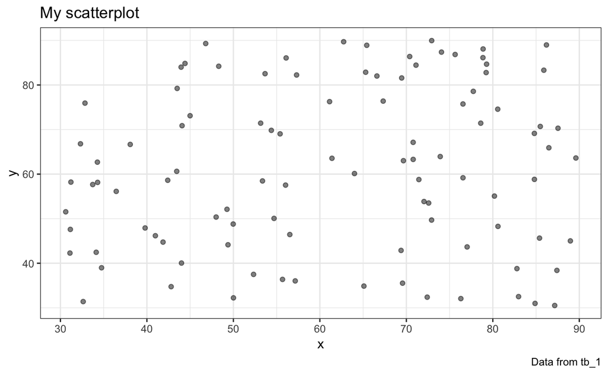

```r
library(tidyverse)

plot_scatter <- function(my_data) {

  ggplot(data = my_data) +
    geom_point(aes(x = x, y = y), alpha = .5) +
    labs(title = "My scatterplot",
         caption = paste0("Data from ", deparse(substitute(my_data)))) +
    theme_bw()

}

# Check:
plot_scatter(my_data = tb_1)
```

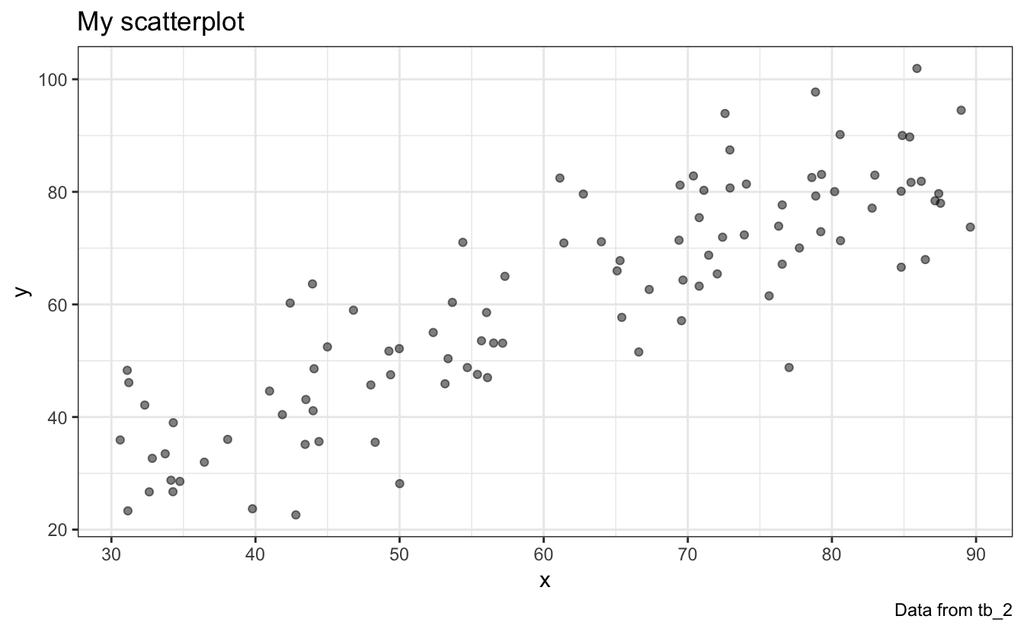

```r
plot_scatter(my_data = tb_2)
```

2. For any table `my_data` that contains 2 numeric variables `x` and `y` we can fit a linear model as follows:

```r
my_data <- tb_1

my_lm <- lm(y ~ x, data = my_data)
my_lm
```

```
#>
#> Call:
#> lm(formula = y ~ x, data = my_data)
#>
#> Coefficients:
#> (Intercept)            x
#>     53.2340       0.1318
```

```r
# Get the model's intercept and slope values:
my_lm$coefficients[1]  # intercept
```

```
#> (Intercept)
#>    53.23402
```

```r
my_lm$coefficients[2]  # slope
```

```
#>         x
#> 0.1318431
```

Incorporate the fit of a linear model into your `plot_scatter` function. Use a linear model to add a line to your plot that shows the prediction of the linear model (in a color that can be set by an optional `col` argument).

#### Solution

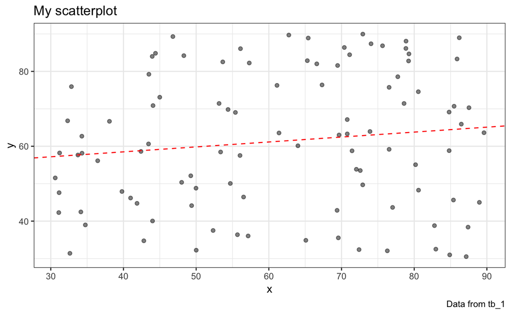

```r
plot_scatter <- function(my_data, col = "red") {

  # fit linear model:
  lm <- lm(y ~ x, data = my_data)
  intercept <- lm$coefficients[1]
  slope <- lm$coefficients[2]

  # plot:
  ggplot(data = my_data) +
    geom_point(aes(x = x, y = y), alpha = .5) +
    geom_abline(intercept = intercept, slope = slope, color = col, lty = 2) +
    labs(title = "My scatterplot",
         caption = paste0("Data from ", deparse(substitute(my_data)))) +
    theme_bw()

}

# Check:
plot_scatter(my_data = tb_1)
```

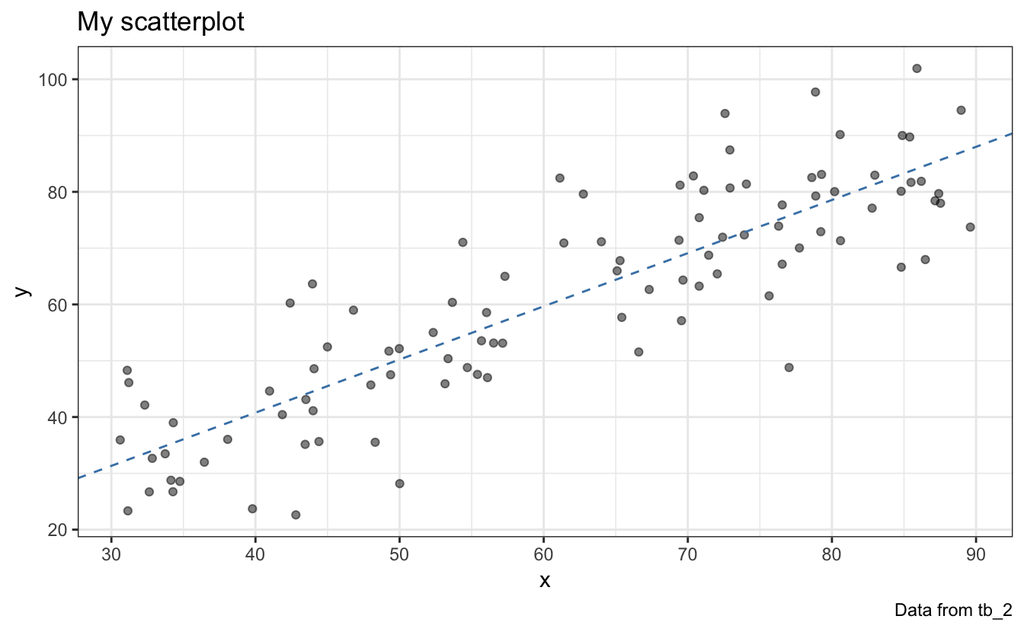

```r
plot_scatter(my_data = tb_2, col = "steelblue")
```

# More on functions

- See the [contributed cheatsheets](https://www.rstudio.com/resources/cheatsheets/) on *Base R* and *Advanced R*.
- [Chapter 19: Functions](https://r4ds.had.co.nz/functions.html) of [r4ds](https://r4ds.had.co.nz/) provides some additional remarks on the special dot-dot-dot argument (`...`), return values, pipeable functions, and the notion of a function’s *environment* or the *scope* of variables.
- To really understand how functions are evaluated and used in R, [Advanced R](http://adv-r.had.co.nz/) devotes chapters on [functions](http://adv-r.had.co.nz/Functions.html), on [environments](http://adv-r.had.co.nz/Environments.html), and on [functional programming](http://adv-r.had.co.nz/Functional-programming.html).
- The `dplyr` [vignette on programming](https://dplyr.tidyverse.org/articles/programming.html) (see `vignette("programming")`) explains some specifics that matter for writing tidyverse functions.

# Conclusion

All [ds4psy](http://rpository.com/ds4psy/) essentials so far:

| Nr. | Topic |
| --- | --- |
| 0. | [Syllabus](http://rpository.com/ds4psy/) |
| 1. | [Basic R concepts and commands](http://rpository.com/ds4psy/essentials/basics.html) |
| 2. | [Visualizing data](http://rpository.com/ds4psy/essentials/visualize.html) |
| 3. | [Transforming data](http://rpository.com/ds4psy/essentials/transform.html) |
| 4. | [Exploring data (EDA)](http://rpository.com/ds4psy/essentials/explore.html) |
| 5. | [Tibbles](http://rpository.com/ds4psy/essentials/tibbles.html) |
| 6. | [Importing data](http://rpository.com/ds4psy/essentials/import.html) |
| 7. | [Tidying data](http://rpository.com/ds4psy/essentials/tidy.html) |
| 8. | [Joining data](http://rpository.com/ds4psy/essentials/join.html) |
| 9. | **Functions** [*](http://rpository.com/ds4psy/essentials/function.html) |
| 10. | [Iteration](http://rpository.com/ds4psy/essentials/iteration.html) |
| +. | [Datasets](http://rpository.com/ds4psy/essentials/datasets.html) |

[Last update on 2019-05-29 10:04:11 by [hn](http://neth.de/).]

[^1]: We can print the definition of any function by typing it at the prompt of the console (without parentheses). However, the fact that we have been using functions like `summarise` or `gather` many times without ever looking up their definitions indicates that we typically rely on examples and documentation for understanding functions.
[^2]: In most functions, the `return()` statement is the final statement of the function `<body>`. See [Chapter 19.6: Return values](https://r4ds.had.co.nz/functions.html#return-values) for special cases in which it makes sense to provide earlier and multiple `return` statements or provide `invisible` return values (e.g., to write pipeable functions).
[^3]: Strictly speaking, we have also been using statements that were processed from left-to-right (e.g., assignments like `x <- 1`) or bottom-to-top (e.g., when assigning a multi-line pipe of `dplyr` statements to an object). Also, given that we have been using functions all along, we have been jumping around in base R code ever since the 1st session.